# Code Notebook

Eileena Mathews, Hayden Pozzi, Rachel Perry, and Richard Liu

2025-10-16

## Introduction

In recent years, artificial intelligence (AI) has undergone a profound shift in public perception. Once seen primarily as a source of uncertainty or even risk, AI is now becoming something people feel increasingly comfortable with—if not socially or professionally expected to use. From writing assistants and chatbots to algorithmic recommendations in education, finance, and entertainment, AI has become an embedded feature of everyday life.

To ground our analysis, we use the Public Attitudes to AI dataset produced by the Ada Lovelace Institute (UK). This nationally representative survey of ~4,000 adults provides perceptions across multiple AI application domains. Our aim here is a reproducible initial exploration: inspect structure and missingness, perform light cleaning, compute simple summaries, and visualise perceived benefits of AI in hiring.

## Load data

```r
ai_path <- "how-do-people-feel-about-ai-main/262400371_Public Attitudes to AI Raw Data NA (1).csv"
if (!file.exists(ai_path)) stop("Data file not found: ", ai_path)
ai_survey1 <- read_csv(ai_path, show_col_types = FALSE)
glimpse(ai_survey1)
```

```
## Rows: 4,012
## Columns: 715
## $ Respondent_ID                                 <dbl> 1, 3, 4, 6214, 10745, 10…
## $ PV25_LengthInSeconds                          <dbl> 1727, 2119, 1600, 2991, …
## $ PV25_LengthInMinutes                          <dbl> 29, 36, 27, 50, 22, 37, …
## $ PV25_DataCollectionDate                       <chr> "11/30/2022NA0:00:00", "…
## $ PV25_Weight                                   <dbl> 1.4639006, 1.3058677, 1.…
## $ PV25_Mode                                     <dbl> 1, 1, 1, 2, 1, 1, 2, 1, …
## $ CS_Age                                        <dbl> 54, 60, 73, 64, 44, 65, …
## $ CS_Age_Band                                   <dbl> 4, 5, 6, 5, 3, 6, 3, 4, …
## $ RS_DateOfBirth                                <chr> NA, NA, NA, NA, NA, NA, …
## $ RS_Sex                                        <dbl> 2, 2, 2, 2, 2, 1, 1, 2, …
## $ RS_EthnicGroup                                <dbl> 1, 1, 1, 2, 1, 1, 1, 1, …
## $ RS_Ethnicity_Reduced                          <dbl> 1, 1, 1, 1, 1, 1, 1, 1, …
## $ RS_ETHUKEUL16                                 <dbl> 1, 1, 1, 1, 1, 1, 1, 1, …
```

[output cut: 702 more lines]

## Inspect variables and missingness

```r
var_df <- tibble(
  var = names(ai_survey1),
  class = map_chr(ai_survey1, ~ class(.x)[1]),
  missing = map_int(ai_survey1, ~ sum(is.na(.x))),
  unique_vals = map_int(ai_survey1, ~ n_distinct(.x, na.rm = TRUE))
) %>% arrange(desc(missing))

print(var_df, n = 250)
```

```
## # A tibble: 715 × 4
##     var                         class     missing unique_vals
##     <chr>                       <chr>       <int>       <int>
##   1 GOVERNANCE_9                character    3985          27
##   2 BENB_LOAN_7                 character    3976          36
##   3 BENB_RVC_4                  character    3973          39
##   4 CONB_LOAN_12                character    3971          41
##   5 BENB_AW_7                   character    3970          42
##   6 BENB_PS_6                   character    3968          44
##   7 BENB_BC_7                   character    3966          46
##   8 BENB_CCR_5                  character    3963          49
##   9 BENB_CAN_6                  character    3962          50
##  10 BENB_SMC_4                  character    3962          50
##  11 BENB_VR_5                   character    3959          53
##  12 MORECOMF_9                  character    3958          54
```

[output cut: 239 more lines]

## Basic cleaning and derived columns

```r
# Standardise names and add row id
ai_clean <- ai_survey1 %>%
  clean_names() %>%
  mutate(row_id = row_number())

# Detect age column (common names cs_age, csage, cs_age_yrs, age)
age_col <- names(ai_clean)[str_detect(names(ai_clean), regex("\\b(cs_age|csage|age|age_years|cs_age_yrs)\\b", ignore_case = TRUE))] %>% .[1]
if (!is.na(age_col)) {
  ai_clean <- ai_clean %>%
    mutate(age = as.integer(.data[[age_col]])) %>%
    filter(is.na(age) | age >= 17)  # remove implausible 16 if present
}

# Detect sex/gender column
sex_col <- names(ai_clean)[str_detect(names(ai_clean), regex("^rs_sex$|sex|gender", ignore_case = TRUE))] %>% .[1]
if (!is.na(sex_col)) {
  ai_clean <- ai_clean %>%
    mutate(
      sex_raw = as.character(.data[[sex_col]]),
      sex = case_when(
        sex_raw %in% c("1", 1, "Male", "male", "M") ~ "Male",
        sex_raw %in% c("2", 2, "Female", "female", "F") ~ "Female",
        TRUE ~ NA_character_
      )
    )
}

# Detect BENB-like columns and coerce to 0/1 integers where possible
benb_cols <- names(ai_clean)[str_detect(names(ai_clean), regex("^benb|benb_job|benefit|benefits|benb_", ignore_case = TRUE))]
if (length(benb_cols) == 0) {
  benb_cols <- names(ai_clean)[str_detect(names(ai_clean), regex("benefit|benb|job", ignore_case = TRUE))]
}

if (length(benb_cols) > 0) {
  ai_clean <- ai_clean %>%
    mutate(across(all_of(benb_cols), ~ {
      x <- .
      # character encodings -> 1/0
      if (is.character(x)) {
        xl <- str_to_lower(str_trim(x))
        as.integer(if_else(xl %in% c("yes","y","1","selected","true","t"), 1L,
                   if_else(xl %in% c("no","n","0","false","f"), 0L, NA_integer_)))
      } else if (is.logical(x)) {
        as.integer(x)
      } else {
        # numeric-like: keep 1/0, else NA
        xi <- suppressWarnings(as.integer(x))
        if_else(is.na(xi), NA_integer_, xi)
      }
    }))
}
# quick check
glimpse(select(ai_clean, any_of(c("age","sex", benb_cols))))
```

```
## Rows: 4,011
## Columns: 194
## $ age                             <int> 54, 60, 73, 64, 44, 65, 43, 47, 69, 48…
## $ sex                             <chr> "Female", "Female", "Female", "Female"…
## $ rs_big_business_benefits_owners <int> 2, 3, 2, 3, 2, 2, 2, 4, 1, 2, 2, 3, 4,…
## $ rs_benefits_preference          <int> 3, 3, 2, 2, 2, 2, 1, 1, NA, 2, 3, 2, 2…
## $ benb_mp_3                       <int> NA, NA, NA, NA, NA, NA, NA, NA, NA, NA…
## $ benb_mp01                       <int> 1, 1, 0, 0, 1, 0, 1, 1, 1, 1, 1, 1, 0,…
## $ benb_mp02                       <int> 1, 0, 0, 0, 0, 1, 1, 1, 0, 0, 1, 1, 1,…
## $ benb_mp03                       <int> 0, 0, 0, 0, 0, 0, 0, 0, 0, 0, 0, 0, 0,…
## $ benb_mp04                       <int> 0, 0, 1, 1, 0, 0, 0, 0, 0, 0, 0, 0, 0,…
## $ benb_mp05                       <int> 0, 0, 0, 0, 0, 0, 0, 0, 0, 0, 0, 0, 0,…
## $ benb_mp06                       <int> 0, 0, 0, 0, 0, 0, 0, 0, 0, 0, 0, 0, 0,…
## $ benb_mp07                       <int> 0, 0, 0, 0, 0, 0, 0, 0, 0, 0, 0, 0, 0,…
## $ benb_mp08                       <int> 0, 0, 0, 0, 0, 0, 0, 0, 0, 0, 0, 0, 0,…
```

[output cut: 181 more lines]

## Derive overall benefit tallies (unweighted)

```r
# Use cleaned benb columns and treat 1 as selected
if (length(benb_cols) > 0) {
  overall_ben <- ai_clean %>%
    select(all_of(benb_cols)) %>%
    mutate(row_id = row_number()) %>%
    pivot_longer(cols = -row_id, names_to = "benefit_raw", values_to = "selected") %>%
    filter(!is.na(selected) & selected == 1L) %>%
    mutate(benefit = benefit_raw) %>%
    count(benefit) %>%
    mutate(pct = n / sum(n))
} else {
  overall_ben <- tibble(benefit = character(0), n = integer(0), pct = numeric(0))
  message("No BENB-like columns detected. Check variable names and adjust the detection pattern.")
}

overall_ben %>% arrange(desc(pct)) %>% print(n = 50)
```

```
## # A tibble: 161 × 3
##    benefit                             n     pct
##    <chr>                           <int>   <dbl>
##  1 benb_mp01                        2454 0.0324
##  2 benb_mp02                        2125 0.0280
##  3 benb_rvc03                       1723 0.0227
##  4 benb_can01                       1668 0.0220
##  5 benb_ps01                        1562 0.0206
##  6 benb_vass02                      1469 0.0194
##  7 benb_bc01                        1444 0.0190
##  8 benb_rvc01                       1407 0.0186
##  9 benb_vr03                        1335 0.0176
## 10 benb_ccr03                       1333 0.0176
## 11 benb_ccr02                       1332 0.0176
## 12 rs_big_business_benefits_owners  1317 0.0174
```

[output cut: 39 more lines]

## Summary statistics

```r
# Age summaries
if ("age" %in% names(ai_clean)) {
  age_stats <- ai_clean %>%
    summarise(
      n = sum(!is.na(age)),
      mean_age = mean(age, na.rm = TRUE),
      median_age = median(age, na.rm = TRUE),
      sd_age = sd(age, na.rm = TRUE),
      min_age = min(age, na.rm = TRUE),
      max_age = max(age, na.rm = TRUE)
    )
  print(age_stats)
}
```

```
## # A tibble: 1 × 6
##       n mean_age median_age sd_age min_age max_age
##   <int>    <dbl>      <int>  <dbl>   <int>   <int>
## 1  4005     48.1         47   17.2      18      94
```

```r
# Sex / gender distribution
if ("sex" %in% names(ai_clean)) {
  print(ai_clean %>% count(sex, sort = TRUE) %>% mutate(p = n / sum(n)))
}
```

```
## # A tibble: 3 × 3
##   sex        n        p
##   <chr>  <int>    <dbl>
## 1 Female  2096 0.523
## 2 Male    1911 0.476
## 3 <NA>       4 0.000997
```

```r
# Top benefits preview
if (exists("overall_ben") && nrow(overall_ben) > 0) {
  print(overall_ben %>% arrange(desc(pct)) %>% slice_head(n = 10))
}
```

```
## # A tibble: 10 × 3
##    benefit         n    pct
##    <chr>       <int>  <dbl>
##  1 benb_mp01    2454 0.0324
##  2 benb_mp02    2125 0.0280
##  3 benb_rvc03   1723 0.0227
##  4 benb_can01   1668 0.0220
##  5 benb_ps01    1562 0.0206
##  6 benb_vass02  1469 0.0194
##  7 benb_bc01    1444 0.0190
##  8 benb_rvc01   1407 0.0186
##  9 benb_vr03    1335 0.0176
## 10 benb_ccr03   1333 0.0176
```

## Visualisations

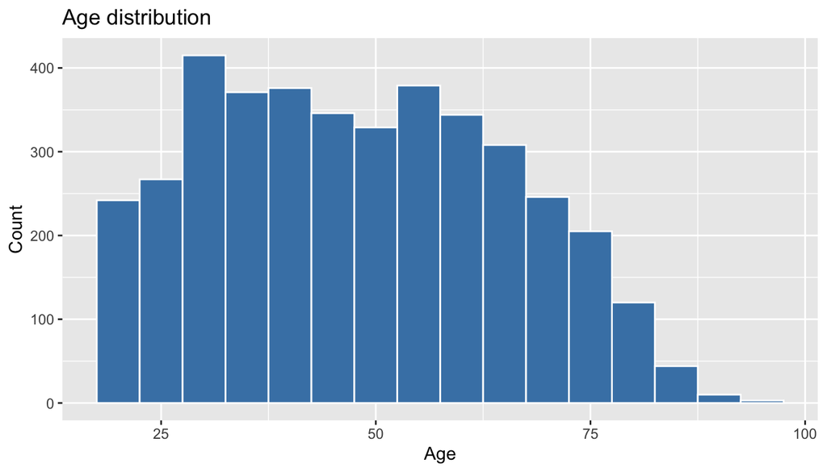

```r
# Age histogram
if ("age" %in% names(ai_clean)) {
  ggplot(filter(ai_clean, !is.na(age)), aes(age)) +
    geom_histogram(binwidth = 5, fill = "steelblue", color = "white") +
    labs(title = "Age distribution", x = "Age", y = "Count")
}
```

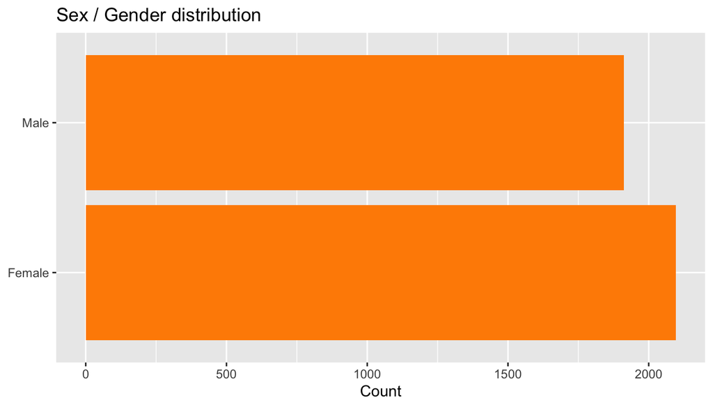

```r
# Sex / gender bar
if ("sex" %in% names(ai_clean)) {
  ggplot(filter(ai_clean, !is.na(sex)), aes(x = fct_infreq(sex))) +
    geom_bar(fill = "darkorange") +
    coord_flip() +
    labs(title = "Sex / Gender distribution", x = NULL, y = "Count")
}
```

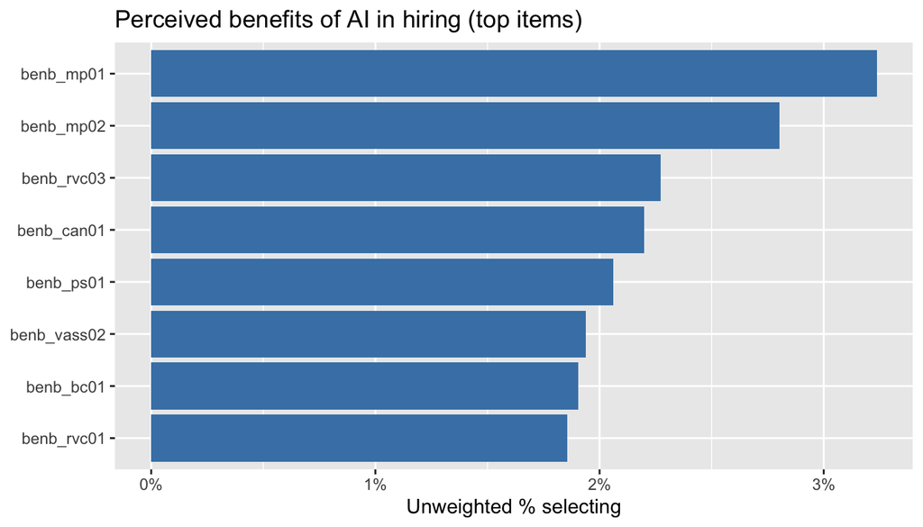

```r
# Benefits bar (top 8)
if (exists("overall_ben") && nrow(overall_ben) > 0) {
  top8 <- overall_ben %>% slice_max(pct, n = 8) %>% pull(benefit)
  overall_ben %>%
    filter(benefit %in% top8) %>%
    ggplot(aes(reorder(benefit, pct), pct)) +
    geom_col(fill = "steelblue") +
    coord_flip() +
    scale_y_continuous(labels = percent) +
    labs(x = NULL, y = "Unweighted % selecting",
         title = "Perceived benefits of AI in hiring (top items)")
}
```

## Notes and next steps

- Confirm BENB column names and encoding (1/0 vs “Yes”/“No”) and update detection patterns if necessary.
- If a survey weight column exists (common names: weight, wt, wgt), compute weighted percentages before reporting final estimates.
- Follow-up: demographic cross-tabs, subgroup comparison plots, and simple regression models.